# Projet Camille Schittly

### Validité du modèle

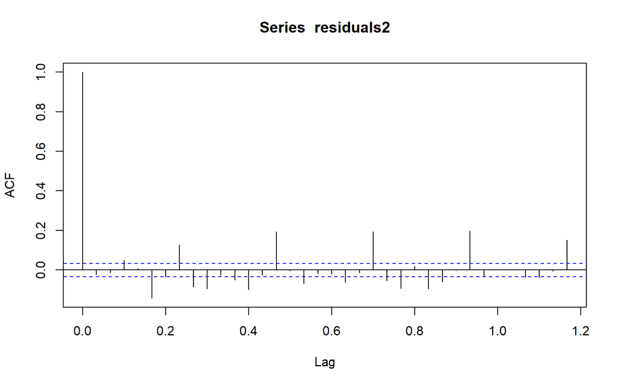

```r
library(stats)
Xj2 = ts(dfj$Prixm, frequency= 30)

sarima_model2 <-  arima(Xj2, order = c(3, 1, 3), seasonal = list(order = c(0, 0, 1), period = 30))

residuals2 = residuals(sarima_model2, data=dfj)

acf(residuals2)
```

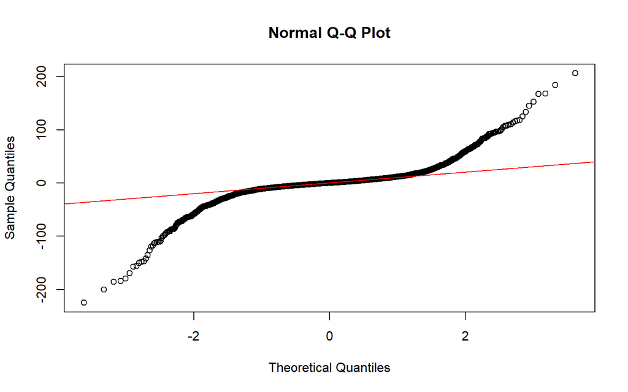

```r
qqnorm(residuals2)
qqline(residuals2, col = "red")
```

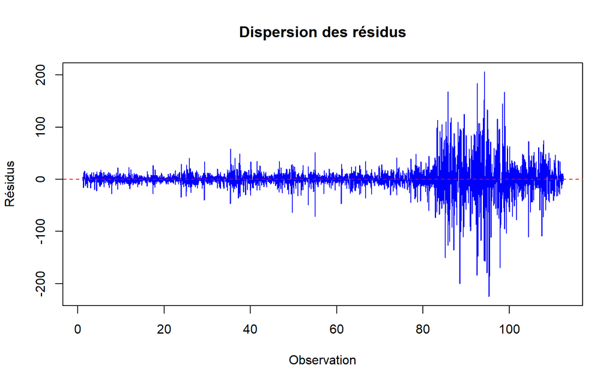

```r
plot(residuals2, pch = 16, col = "blue", xlab = "Observation", ylab = "Résidus",
     main = "Dispersion des résidus")

abline(h = 0, col = "red", lty = 2)
```

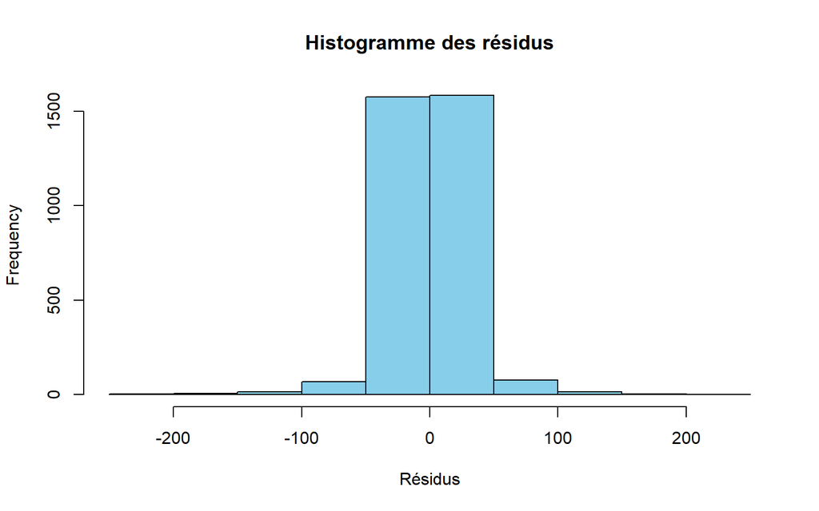

```r
hist(residuals2, col = "skyblue", main = "Histogramme des résidus", xlab = "Résidus")
```

En examinant le graphique, on regarde si les résidus ont une dispersion similaire autour de zéro sur l’ensemble des données. La dispersion des résidus semble est plus ou moins uniforme et similaire à travers au début des données, cela suggère que les variances sont égales au début.

Ce qui rend ce modèle pas si adéquat est la présence de valeurs aberante en 2023.

# Exercice 2

## Importation des données

Tout d’abord on importe les données

```r
library(tidyverse)
library(readr)
library(dplyr)


dataair = read_csv("death-rate-from-air-pollution-per-100000.csv",na = c(":"), show_col_types = FALSE)
dataair = dataair %>% rename('deces'= `Deaths that are from all causes attributed to air pollution per 100,000 people, in both sexes aged age-standardized`
)


dataNRJ1 = read_csv("energy-consumption-by-source-and-country.csv", na = c(":"),show_col_types = FALSE)
```

```r
dataNRJ2 = dataNRJ1 %>%
  rename ('NRJsolaire' = `Solar consumption - TWh`) %>% rename('NRJvent'= `Wind consumption - TWh`)%>%rename('NRJautre'= `Other renewables (including geothermal and biomass) - TWh`) %>%rename('NRJbiocarb'= `Biofuels consumption - TWh`)%>%rename('NRJhydro'= `Hydro consumption - TWh`) %>%rename('NRJnucl'= `Nuclear consumption - TWh`) %>%rename('NRJgaz'= `Gas consumption - TWh`) %>%
  rename('NRJhuile'= `Oil consumption - TWh`) %>%rename('NRJcharbon'= `Coal consumption - TWh`)

datapopu = read_csv("population-and-demography.csv", na = c(":"),show_col_types = FALSE)

datapop1 = datapopu[,c(1,2,3)]
```

## Carte

Voici une carte qui montre le nombre de décès attribués à la pollution de l’air, toutes causes confondues, pour 100 000 personnes, chez les deux sexes, ajusté selon l’âge standardisé en 2010

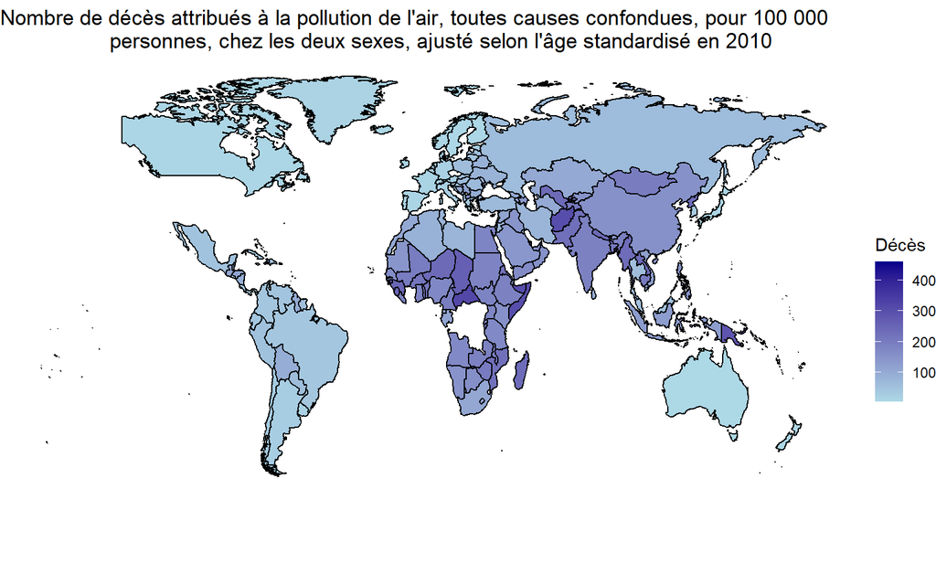

```r
library(ggplot2)
library(dplyr)
library(maps)

dataair2010 = dataair %>% filter(Year == 2010)
world_map = map_data("world")


ggplot(data = dataair2010, aes(fill = deces, map_id = Entity)) +
  geom_map(map = world_map, color = "black") +labs(title = "Nombre de décès attribués à la pollution de l'air, toutes causes confondues, pour 100 000
                  personnes, chez les deux sexes, ajusté selon l'âge standardisé en 2010")+
  expand_limits(x = world_map$long, y = world_map$lat) +
  scale_fill_gradient(name = "Décès", low = "lightblue", high = "darkblue") +
  theme_void()
```

On peut constater que c’est en Afrique et en Asie qu’il y a le plus de dècès dû à la pollution de l’air.

## Mettre à la bonne échelle

Ici, nous n’avons pas les données par habitant donc il est important de changer les données.

Pour la consommation d’énergie, nous avons les données pour le pays donc il faut le changer pour rendre les données par habitant

```r
datapop =datapop1 %>% rename("Entity"= "Country name")
# Étape 1 : Joindre les données avec les données de population
dataNRJ3 <- full_join(dataNRJ2, datapop, by = c("Year", "Entity"))
dataNRJ3
```

```
## # A tibble: 19,626 × 13
##    Entity Code   Year NRJautre NRJbiocarb NRJsolaire NRJvent NRJhydro NRJnucl
##    <chr>  <chr> <dbl>    <dbl>      <dbl>      <dbl>   <dbl>    <dbl>   <dbl>
##  1 Africa ""     1971    0.524         NA          0       0     76.9       0
##  2 Africa ""     1972    0.527         NA          0       0     87.6       0
##  3 Africa ""     1973    0.543         NA          0       0     92.7       0
##  4 Africa ""     1974    0.559         NA          0       0    105.        0
##  5 Africa ""     1975    0.549         NA          0       0    112.        0
##  6 Africa ""     1976    0.591         NA          0       0    124.        0
##  7 Africa ""     1977    0.603         NA          0       0    136.        0
##  8 Africa ""     1978    0.622         NA          0       0    137.        0
##  9 Africa ""     1979    0.642         NA          0       0    147.        0
## 10 Africa ""     1980    0.661         NA          0       0    143.        0
## # ℹ 19,616 more rows
## # ℹ 4 more variables: NRJgaz <dbl>, NRJcharbon <dbl>, NRJhuile <dbl>,
## #   Population <dbl>
```

```r
# Étape 2 : Calculer les données par personne
dataNRJppers1 <- dataNRJ3 %>%
  mutate(NRJautre = NRJautre / Population)%>% mutate(NRJbiocarb = NRJbiocarb / Population) %>% mutate(NRJsolaire = NRJsolaire / Population) %>% mutate(NRJvent = NRJvent / Population) %>% mutate(NRJhydro = NRJhydro / Population ) %>% mutate(NRJnucl = NRJnucl / Population) %>% mutate(NRJgaz = NRJgaz / Population) %>% mutate(NRJcharbon = NRJcharbon / Population) %>% mutate(NRJhuile = NRJhuile / Population)
dataNRJppers = dataNRJppers1[,c(1:12)]
```

De même pour les données concernant les decès dus à la pollution de l’air

```r
dataairppers <- dataair %>%
  mutate(deces = deces /100000)
```

Maintenant que nous avons les données par habitant nous pouvons joindre les données pour les mettre dans un seul endroit.

```r
library(dplyr)

datajoin =full_join(dataNRJppers, dataairppers,  by = c("Year", "Entity", "Code"))
df = na.omit(datajoin)
dfe = df %>% filter(Year== 2007 | Year == 2017 )
df
```

```
## # A tibble: 1,350 × 13
##    Entity    Code   Year NRJautre NRJbiocarb NRJsolaire NRJvent NRJhydro NRJnucl
##    <chr>     <chr> <dbl>    <dbl>      <dbl>      <dbl>   <dbl>    <dbl>   <dbl>
##  1 Argentina ARG    2010  1.07e-7    1.44e-7   5.80e-12 1.71e-9  2.25e-6 4.67e-7
##  2 Argentina ARG    2011  1.07e-7    2.09e-7   1.07e-10 1.77e-9  2.07e-6 4.08e-7
##  3 Argentina ARG    2012  1.11e-7    2.48e-7   5.34e-10 2.42e-8  1.91e-6 4.02e-7
##  4 Argentina ARG    2013  1.15e-7    2.81e-7   9.69e-10 2.91e-8  2.11e-6 3.83e-7
##  5 Argentina ARG    2014  1.11e-7    3.24e-7   1.01e- 9 3.92e-8  2.05e-6 3.35e-7
##  6 Argentina ARG    2015  1.10e-7    3.50e-7   9.14e-10 3.69e-8  2.01e-6 4.21e-7
##  7 Argentina ARG    2016  8.60e-8    3.67e-7   8.75e-10 3.36e-8  1.82e-6 4.87e-7
##  8 Argentina ARG    2017  1.06e-7    4.18e-7   9.92e-10 3.69e-8  1.91e-6 3.53e-7
##  9 Argentina ARG    2018  1.02e-7    3.96e-7   6.44e- 9 8.42e-8  1.92e-6 3.93e-7
## 10 Argentina ARG    2019  1.05e-7    4.02e-7   4.71e- 8 2.94e-7  1.62e-6 4.77e-7
## # ℹ 1,340 more rows
## # ℹ 4 more variables: NRJgaz <dbl>, NRJcharbon <dbl>, NRJhuile <dbl>,
## #   deces <dbl>
```

## Densité du dèces

On peut se poser la question de ce qu’est la densité du nombre de décès ainsi que les statistique descriptive.

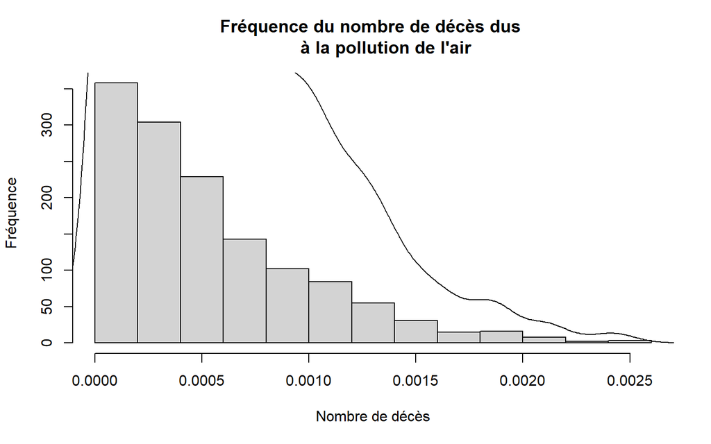

```r
library(graphics)


hist(df$deces, main = "Fréquence du nombre de décès dus
     à la pollution de l'air", xlab = "Nombre de décès", ylab = "Fréquence")

# Ajouter la densité avec lines()
lines(density(df$deces, na.rm = TRUE))
```

## Statistique descriptive

```r
summary(df)
```

```
##     Entity              Code                Year         NRJautre
##  Length:1350        Length:1350        Min.   :1990   Min.   :0.000e+00
##  Class :character   Class :character   1st Qu.:2000   1st Qu.:3.043e-08
##  Mode  :character   Mode  :character   Median :2007   Median :1.611e-07
##                                        Mean   :2006   Mean   :5.945e-07
##                                        3rd Qu.:2013   3rd Qu.:6.131e-07
##                                        Max.   :2019   Max.   :3.116e-05
##    NRJbiocarb          NRJsolaire           NRJvent
##  Min.   :0.000e+00   Min.   :0.000e+00   Min.   :0.000e+00
##  1st Qu.:0.000e+00   1st Qu.:0.000e+00   1st Qu.:2.880e-10
##  Median :1.622e-08   Median :5.975e-10   Median :2.747e-08
##  Mean   :1.357e-07   Mean   :8.712e-08   Mean   :3.976e-07
##  3rd Qu.:1.688e-07   3rd Qu.:3.004e-08   3rd Qu.:3.299e-07
##  Max.   :2.402e-06   Max.   :1.902e-06   Max.   :7.345e-06
##     NRJhydro            NRJnucl              NRJgaz
##  Min.   :0.000e+00   Min.   :0.000e+00   Min.   :0.000e+00
##  1st Qu.:2.786e-07   1st Qu.:0.000e+00   1st Qu.:3.180e-06
##  Median :1.189e-06   Median :1.389e-07   Median :6.683e-06
##  Mean   :3.958e-06   Mean   :3.133e-06   Mean   :7.837e-06
##  3rd Qu.:2.740e-06   3rd Qu.:5.483e-06   3rd Qu.:1.077e-05
##  Max.   :8.194e-05   Max.   :2.534e-05   Max.   :3.138e-05
##    NRJcharbon           NRJhuile             deces
##  Min.   :5.350e-09   Min.   :1.175e-06   Min.   :2.661e-05
##  1st Qu.:1.991e-06   1st Qu.:7.021e-06   1st Qu.:1.884e-04
##  Median :5.565e-06   Median :1.255e-05   Median :4.154e-04
##  Mean   :8.059e-06   Mean   :1.511e-05   Mean   :5.367e-04
##  3rd Qu.:1.105e-05   3rd Qu.:2.021e-05   3rd Qu.:7.600e-04
##  Max.   :4.585e-05   Max.   :8.036e-05   Max.   :2.476e-03
```

## Représentation graphique

On fait un nuage de points

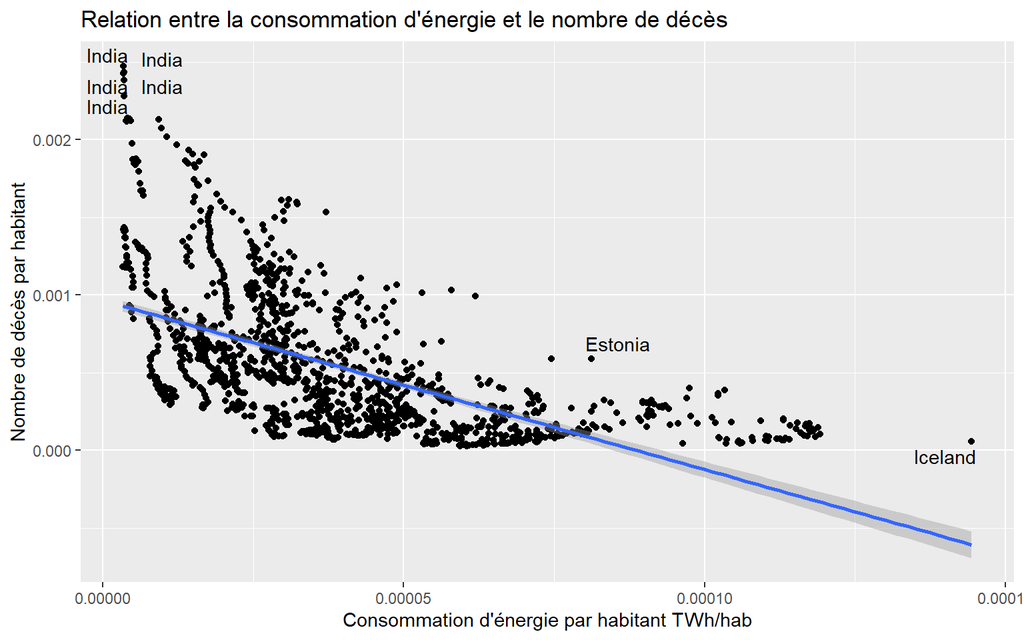

```r
library(ggrepel)

ggplot(df, aes(x = NRJautre + NRJbiocarb + NRJsolaire + NRJvent + NRJhydro + NRJnucl + NRJgaz +NRJcharbon + NRJhuile , y =deces)) +
  geom_point() +
  geom_text_repel(aes(label = Entity))+
  geom_smooth(method = "lm", se = TRUE) +
  xlab("Consommation d'énergie par habitant TWh/hab") +
  ylab("Nombre de décès par habitant") +
  labs(title = "Relation entre la consommation d'énergie et le nombre de décès ")
```

Ici on peut constater que le nuage de point et la droite de régression ne coincide pas trop.

## Régression linéaire

Une facon de liées des variable quantitative et de faire une régression linéaire Ici on souhaite donner un modèle liant la mortatilité due à la pollution de l’air et la consomation par habitant de different type d’énergie.

Voici le modèle de régression donné avec $p = 9$ :

$$Y = \beta_0 + \sum_{j=1}^{9} \beta_j x_j + \epsilon$$

où $Y$, $x_1, \ldots, x_9$, $\epsilon \in \mathbb{R}$, avec $p \in \mathbb{N}$ et $E[\epsilon] = 0$. On observe $\{ (Y_i, x_{i,1}, \ldots, x_{i,9}), 1 \leq i \leq n \}$ à partir duquel on veut estimer $(\beta_0, \beta_1, \ldots, \beta_9)^\top \in \mathbb{R}^{9+1}$.

Voici le modèle de régression avec les notations de l’exercice:

$$decès = \beta_0 + \beta_1 \times
NRJautre + ... + \beta_9 \times NRJhuile + \epsilon$$
Le coefficient $\beta_{0}$ (Intercept) nous indique la moyenne attendue de dèces lorsque toutes les variables explicatives sont nulles.

Une régression linéaire doit vérifier plusieurs hypothèses :

- La linéarité du modèle
- La variance des résidus est constante $\sigma^2$ (homoscédasticité)
- Les résidus sont indépendants
- Les résidus sont issus d’une loi normales de moyenne nulle et de variance $\sigma^2$

Nous allons étudier ce modele avec les données concernant les pays.

```r
library(tidyverse)
library(dplyr)
library(broom)

model = lm(formula =  deces ~ ((NRJautre) + (NRJbiocarb) + (NRJsolaire) + (NRJvent) + (NRJhydro) + (NRJnucl) + (NRJgaz) + (NRJcharbon) + (NRJhuile))   , data = df)


summary(model)
```

```
##
## Call:
## lm(formula = deces ~ ((NRJautre) + (NRJbiocarb) + (NRJsolaire) +
##     (NRJvent) + (NRJhydro) + (NRJnucl) + (NRJgaz) + (NRJcharbon) +
##     (NRJhuile)), data = df)
##
## Residuals:
##        Min         1Q     Median         3Q        Max
## -5.583e-04 -2.177e-04 -7.662e-05  1.785e-04  1.530e-03
##
## Coefficients:
##               Estimate Std. Error t value Pr(>|t|)
## (Intercept)  9.694e-04  1.793e-05  54.074  < 2e-16 ***
## NRJautre    -4.105e+01  7.350e+00  -5.585 2.83e-08 ***
## NRJbiocarb  -4.876e+01  4.118e+01  -1.184 0.236671
## NRJsolaire  -2.564e+02  4.531e+01  -5.659 1.86e-08 ***
## NRJvent     -9.592e+01  1.243e+01  -7.714 2.36e-14 ***
## NRJhydro    -5.910e+00  1.058e+00  -5.588 2.78e-08 ***
## NRJnucl     -1.070e+01  1.945e+00  -5.501 4.53e-08 ***
## NRJgaz      -5.981e+00  1.737e+00  -3.444 0.000591 ***
## NRJcharbon  -7.788e-01  1.208e+00  -0.645 0.519178
## NRJhuile    -1.529e+01  1.075e+00 -14.224  < 2e-16 ***
## ---
## Signif. codes:  0 '***' 0.001 '**' 0.01 '*' 0.05 '.' 0.1 ' ' 1
##
## Residual standard error: 0.0003276 on 1340 degrees of freedom
## Multiple R-squared:  0.4753, Adjusted R-squared:  0.4718
## F-statistic: 134.9 on 9 and 1340 DF,  p-value: < 2.2e-16
```

```r
confint(model)
```

```
##                     2.5 %        97.5 %
## (Intercept)  9.341877e-04  1.004522e-03
## NRJautre    -5.546562e+01 -2.662795e+01
## NRJbiocarb  -1.295457e+02  3.203451e+01
## NRJsolaire  -3.453066e+02 -1.675258e+02
## NRJvent     -1.203165e+02 -7.153004e+01
## NRJhydro    -7.984119e+00 -3.835009e+00
## NRJnucl     -1.451233e+01 -6.882299e+00
## NRJgaz      -9.387145e+00 -2.573871e+00
## NRJcharbon  -3.148381e+00  1.590730e+00
## NRJhuile    -1.740207e+01 -1.318378e+01
```

## Sélection et interprétation du modèle

### Interpretation

Les écart-types nous permettent de décrire la précision de l’estimation des paramètres, plus la variance est faible plus l’estimateur est précis.

#### Test de significativité globale du modèle

$H_0$ : Absence de significativité globale des variables.

$H_1$ : Significativité des variables

Je choisi comme seuil, un seuil $\alpha$ de 5%.

On a p-value < 2.2e-16 < 5% , on peut dire que l’on rejète $H_0$, à savoir le modèle est bien globalement significatif.

### Interprétation des coefficients

#### Significativité

$H_0$ : Le coefficient est bien significativement différent de zéro

$H_1$ : Le coefficient n’est pas significativement différent de zéro

Je choisi un seuil $\alpha$ de 5%.

Si la p-value est inférieure au seuil de significativité, alors on concluera que le paramètre est significativement différent de 0.

Ainsi il y a un coefficiant non significatif d’un point de vue statistique à savoir NRJcharbon dont la p-value est de 0.519178 et NRJbiocarb avec une p-value de 0.236671

#### Signe du coefficient

Avec un modèle linéaire, le signe du coefficient associé à une variable indique le sens de l’effet de cette variable sur la variable à expliquer.Ici les coefficients de l’energie consommé sont souvent négatifs. Ce qui correspond à l’allure du nuage de point qui va vers le bas

#### Qualité du modèle

Nous regardons le $R^2_{aj}$,Ici il est de 0.4718 ce qui n’est pas très proche de 1

## Ajustement

```r
model1aj = lm(formula =  deces ~ NRJautre  + NRJsolaire + NRJvent + NRJhydro + NRJnucl + NRJgaz  + NRJhuile   , data = df)


summary(model1aj)
```

```
##
## Call:
## lm(formula = deces ~ NRJautre + NRJsolaire + NRJvent + NRJhydro +
##     NRJnucl + NRJgaz + NRJhuile, data = df)
##
## Residuals:
##        Min         1Q     Median         3Q        Max
## -5.621e-04 -2.163e-04 -7.701e-05  1.787e-04  1.533e-03
##
## Coefficients:
##               Estimate Std. Error t value Pr(>|t|)
## (Intercept)  9.645e-04  1.603e-05  60.161  < 2e-16 ***
## NRJautre    -4.161e+01  7.329e+00  -5.677 1.68e-08 ***
## NRJsolaire  -2.645e+02  4.477e+01  -5.907 4.40e-09 ***
## NRJvent     -1.005e+02  1.160e+01  -8.664  < 2e-16 ***
## NRJhydro    -5.894e+00  1.036e+00  -5.688 1.58e-08 ***
## NRJnucl     -1.082e+01  1.940e+00  -5.578 2.93e-08 ***
## NRJgaz      -5.983e+00  1.736e+00  -3.446 0.000587 ***
## NRJhuile    -1.561e+01  1.040e+00 -15.011  < 2e-16 ***
## ---
## Signif. codes:  0 '***' 0.001 '**' 0.01 '*' 0.05 '.' 0.1 ' ' 1
##
## Residual standard error: 0.0003275 on 1342 degrees of freedom
## Multiple R-squared:  0.4747, Adjusted R-squared:  0.472
## F-statistic: 173.3 on 7 and 1342 DF,  p-value: < 2.2e-16
```

Ici la seule différence à noter est que les coefficiants sont maintenant significatif, néanmoins le $R^2$ est plus petit car un sous modèle a toujours un $R^2$ plus petit.

## Test d’hypothèse

Ce qui pourrait faire que le modèle n’est pas très bon est le fait que l’une des hypothèse ne soient pas vérifié.

Nous allons utliser des graphiques afin de vérifier si les conditions d’application du modèle sont vérifier

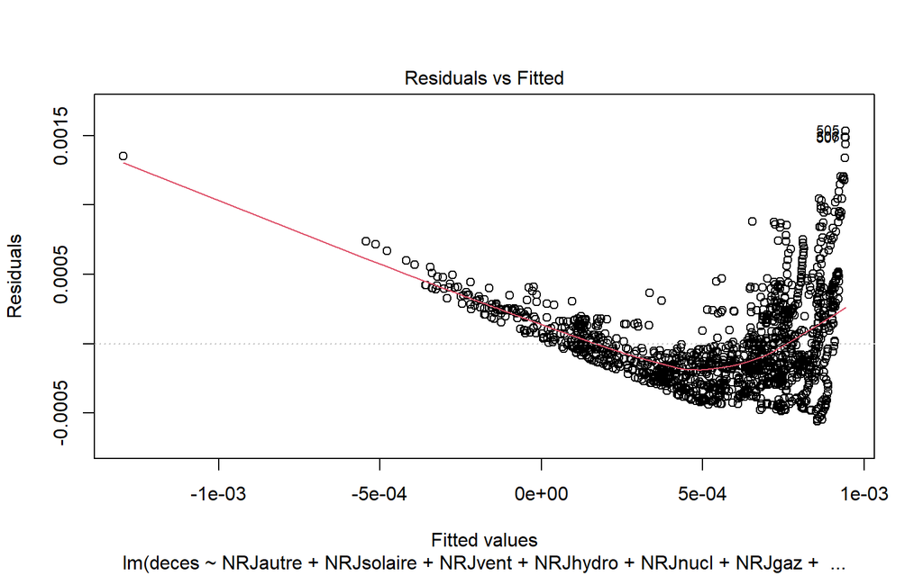

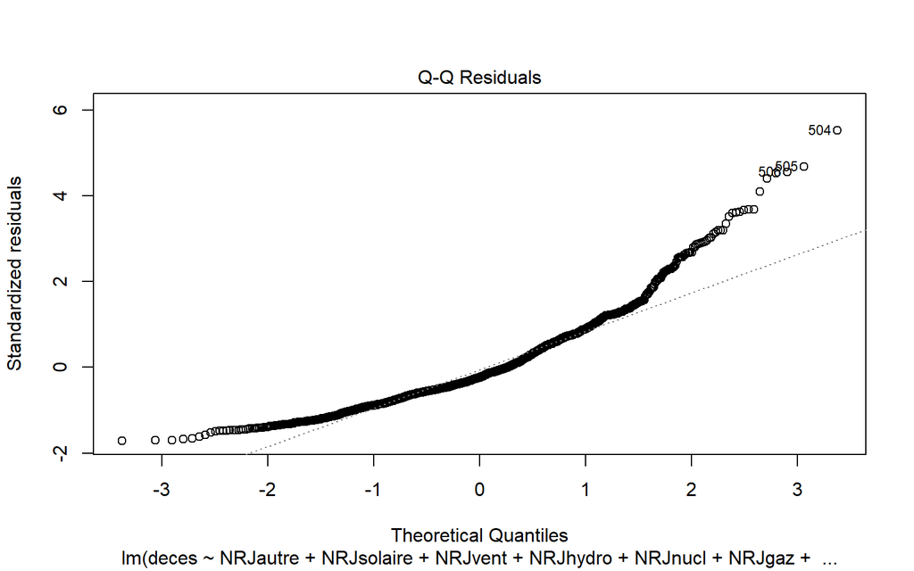

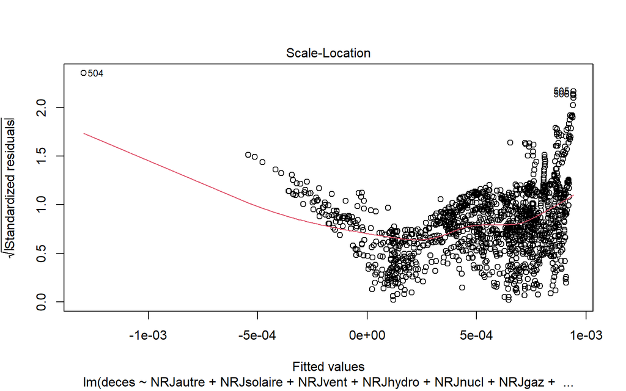

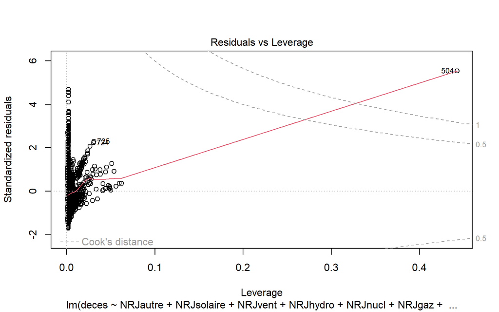

```r
# Conditions d'application
#par(mfrow=c(2,2))
plot(model1aj)
```

### Normalité

```r
shapiro.test(residuals(model1aj))
```

```
##
##  Shapiro-Wilk normality test
##
## data:  residuals(model1aj)
## W = 0.91615, p-value < 2.2e-16
```

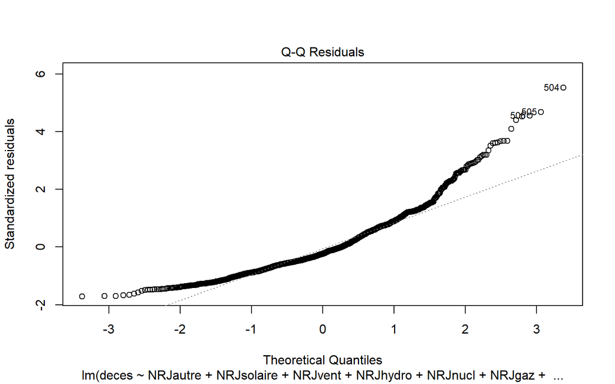

```r
plot(model1aj,2)
```

Je choisi un seuil $\alpha = 0.01$

Le test de shapiro indique une p-valeurs < 2.2e-16

La p-value est inférieur au niveau $\alpha$ choisi, alors l’hypotèse $H_0$ d’un échantillon provenant d’une population suit une loi normale est rejetée.

Néanmoins comme il y a beaucoup d’observations on peut regarder le QQ plot, et voir que la majorité des points suivent la droite de Henry.

### Indépendence des résidus

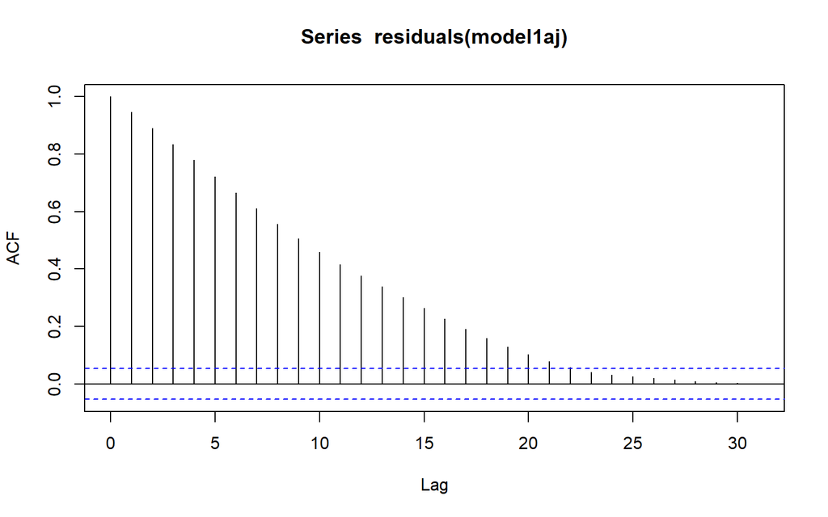

```r
library(see)
library(car)

acf(residuals(model1aj))
```

En regardant l’autocorrélogramme, on voit qu’il y a colinéarité entre les résidus.

### Evaluation de l’hypothèse d’homogénéité des résidus

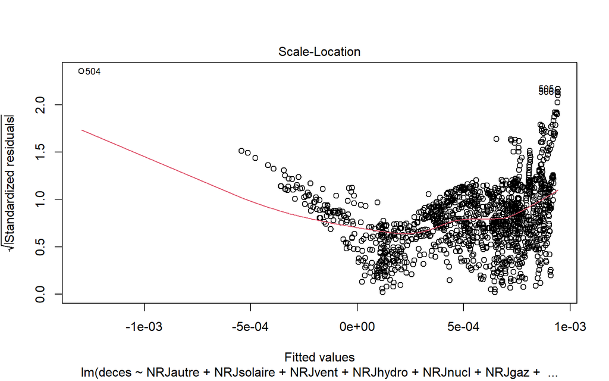

```r
plot(model1aj, 3)
```

```r
ncvTest(model1aj)
```

```
## Non-constant Variance Score Test
## Variance formula: ~ fitted.values
## Chisquare = 122.8508, Df = 1, p = < 2.22e-16
```

Je choisi un seuil $\alpha$ de 1%

De même par le graphique on voit que les résidues ne sont pas éparpié de facon homogène et que la ligne rouge ne forme pas une droite ce qui confirme l’idée.

### Evaluation à posteriori de l’hypothèse de linéarité

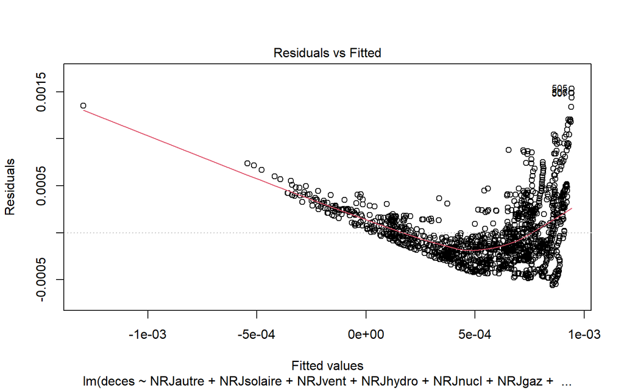

```r
plot(model1aj,1)
```

Ici on devrait avoir une droite rouge mais ce n’est pas le cas et les résidus ne sont pas uniformément distribué de part et d’autre de 0, mais on pouvais déja voir au nuage de point que l’hypothèse de linéarité n’étais pas satisfaite.

Ainsi le modèle présenté n’est pas très bon.

On va chercher quelque chose de mieux.

Déja la linéarité n’étais pas présente donc on peut trouver une transpforamation pour y remédier.

De même il est difficile d’avoir les hypothèses de vérifié quand il y a énormement de valeur.

Je décide donc de prendre le logarithme de ma variable à expliquer et de réduire le nombre de donnée en prenant l’année 2007 et 2017.

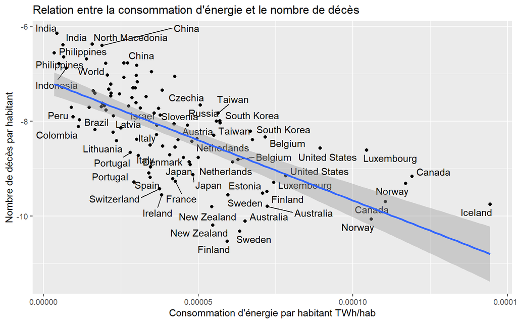

```r
library(ggrepel)
# Créer le graphique
ggplot(dfe, aes(x = NRJautre + NRJbiocarb + NRJsolaire + NRJvent + NRJhydro + NRJnucl + NRJgaz +NRJcharbon + NRJhuile , y =log(deces))) +
  geom_point() +
  geom_text_repel(aes(label = Entity))+
  geom_smooth(method = "lm", se = TRUE) +
  xlab("Consommation d'énergie par habitant TWh/hab") +
  ylab("Nombre de décès par habitant") +
  labs(title = "Relation entre la consommation d'énergie et le nombre de décès ")
```

```r
library(tidyverse)
library(dplyr)
library(broom)

model2 = lm(formula =  log(deces) ~ NRJautre + NRJbiocarb + NRJsolaire + NRJvent + NRJhydro + NRJnucl + NRJgaz + NRJcharbon + NRJhuile   , data = dfe)


summary(model2)
```

```
##
## Call:
## lm(formula = log(deces) ~ NRJautre + NRJbiocarb + NRJsolaire +
##     NRJvent + NRJhydro + NRJnucl + NRJgaz + NRJcharbon + NRJhuile,
##     data = dfe)
##
## Residuals:
##      Min       1Q   Median       3Q      Max
## -1.58320 -0.42102  0.06411  0.42700  1.11409
##
## Coefficients:
##               Estimate Std. Error t value Pr(>|t|)
## (Intercept) -7.043e+00  1.255e-01 -56.139  < 2e-16 ***
## NRJautre    -3.011e+04  2.407e+04  -1.251 0.213821
## NRJbiocarb  -1.936e+04  2.289e+05  -0.085 0.932763
## NRJsolaire  -5.540e+05  2.353e+05  -2.354 0.020580 *
## NRJvent     -3.248e+05  6.169e+04  -5.265 8.41e-07 ***
## NRJhydro    -2.064e+04  5.609e+03  -3.680 0.000383 ***
## NRJnucl     -4.013e+04  1.426e+04  -2.813 0.005935 **
## NRJgaz      -6.448e+03  1.217e+04  -0.530 0.597457
## NRJcharbon  -8.525e+03  8.529e+03  -1.000 0.320035
## NRJhuile    -2.987e+04  8.411e+03  -3.551 0.000594 ***
## ---
## Signif. codes:  0 '***' 0.001 '**' 0.01 '*' 0.05 '.' 0.1 ' ' 1
##
## Residual standard error: 0.6185 on 97 degrees of freedom
## Multiple R-squared:  0.6523, Adjusted R-squared:  0.6201
## F-statistic: 20.22 on 9 and 97 DF,  p-value: < 2.2e-16
```

```r
tidy(model2, conf.int=TRUE)
```

```
## # A tibble: 10 × 7
##    term          estimate  std.error statistic  p.value    conf.low  conf.high
##    <chr>            <dbl>      <dbl>     <dbl>    <dbl>       <dbl>      <dbl>
##  1 (Intercept)      -7.04      0.125  -56.1    9.02e-76       -7.29      -6.79
##  2 NRJautre     -30114.    24065.      -1.25   2.14e- 1   -77877.     17649.
##  3 NRJbiocarb   -19359.   228865.      -0.0846 9.33e- 1  -473594.    434875.
##  4 NRJsolaire  -554045.   235346.      -2.35   2.06e- 2 -1021141.    -86948.
##  5 NRJvent     -324833.    61694.      -5.27   8.41e- 7  -447279.   -202387.
##  6 NRJhydro     -20641.     5609.      -3.68   3.83e- 4   -31773.     -9509.
##  7 NRJnucl      -40133.    14265.      -2.81   5.93e- 3   -68445.    -11821.
##  8 NRJgaz        -6448.    12171.      -0.530  5.97e- 1   -30605.     17708.
##  9 NRJcharbon    -8525.     8529.      -1.00   3.20e- 1   -25453.      8403.
## 10 NRJhuile     -29870.     8411.      -3.55   5.94e- 4   -46564.    -13176.
```

```r
confint(model2)
```

```
##                     2.5 %        97.5 %
## (Intercept) -7.292369e+00 -6.794351e+00
## NRJautre    -7.787676e+04  1.764916e+04
## NRJbiocarb  -4.735937e+05  4.348753e+05
## NRJsolaire  -1.021141e+06 -8.694820e+04
## NRJvent     -4.472789e+05 -2.023866e+05
## NRJhydro    -3.177320e+04 -9.509236e+03
## NRJnucl     -6.844459e+04 -1.182099e+04
## NRJgaz      -3.060461e+04  1.770794e+04
## NRJcharbon  -2.545255e+04  8.402889e+03
## NRJhuile    -4.656365e+04 -1.317571e+04
```

## Sélection et interprétation du modèle

## Interpretation

Les écart-types nous permettent de décrire la précision de l’estimation des paramètres, plus la variance est faible plus l’estimateur est précis.

### Test de significativité globale du modèle

$H_0$ : Absence de significativité globale des variables.

$H_1$ : Significativité des variables

Je choisi comme seuil, un seuil $\alpha$ de 5%.

On a $p-value \lt 2.2e-16 \lt 5$ %, on peut dire que l’on rejète $H_0$, à savoir le modèle est bien globalement significatif.

### Interprétation des coefficients

#### Significativité

$H_0$ : Le coefficient est bien significativement différent de zéro

$H_1$ : Le coefficient n’est pas significativement différent de zéro

Je choisi un seuil $\alpha$ de 5%.

Si la p-value est inférieure au seuil de significativité, alors on concluera que le paramètre est significativement différent de 0.

#### Signe du coefficient

Avec un modèle linéaire, le signe du coefficient associé à une variable indique le sens de l’effet de cette variable sur la variable à expliquer.Ici les coefficients de l’energie consommé sont souvent négatifs. Ce qui correspond à l’allure du nuage de point qui va vers le bas

#### Qualité du modèle

Nous regardons le $R^2_{aj}$,Ici il est de 0.6201 ce qui est mieux que précdemment.

### Ajustement du modèle

Je vais enlever les variable non significative avec la méthode du backward

J’enleve d’abord NRJbiocarb, NRJgaz, NRJcharbon, et enfin NRJautre

```r
modelaj = lm(formula =  log(deces) ~ NRJsolaire + NRJvent + NRJhydro + NRJnucl  + NRJhuile   , data = dfe)


summary(modelaj)
```

```
##
## Call:
## lm(formula = log(deces) ~ NRJsolaire + NRJvent + NRJhydro + NRJnucl +
##     NRJhuile, data = dfe)
##
## Residuals:
##      Min       1Q   Median       3Q      Max
## -1.67537 -0.38034  0.05062  0.42135  1.17055
##
## Coefficients:
##               Estimate Std. Error t value Pr(>|t|)
## (Intercept) -7.113e+00  1.060e-01 -67.117  < 2e-16 ***
## NRJsolaire  -5.641e+05  2.326e+05  -2.425  0.01709 *
## NRJvent     -3.263e+05  5.648e+04  -5.777 8.45e-08 ***
## NRJhydro    -2.301e+04  4.717e+03  -4.878 4.00e-06 ***
## NRJnucl     -4.110e+04  1.394e+04  -2.949  0.00397 **
## NRJhuile    -3.418e+04  5.804e+03  -5.890 5.11e-08 ***
## ---
## Signif. codes:  0 '***' 0.001 '**' 0.01 '*' 0.05 '.' 0.1 ' ' 1
##
## Residual standard error: 0.6146 on 101 degrees of freedom
## Multiple R-squared:  0.6425, Adjusted R-squared:  0.6248
## F-statistic: 36.31 on 5 and 101 DF,  p-value: < 2.2e-16
```

## Test d’hypothèse

Nous allons utliser des graphiques afin de vérifier si les conditions d’application du modèle sont vérifier

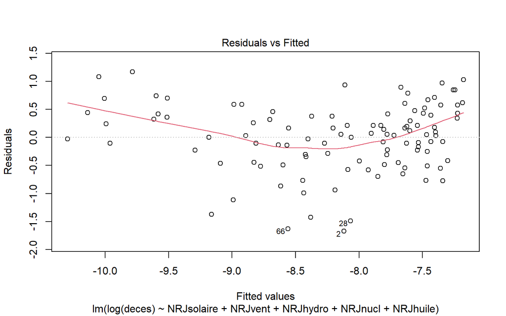

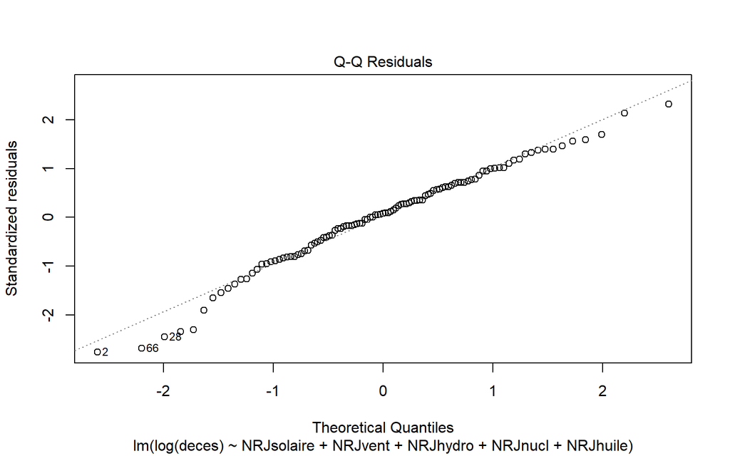

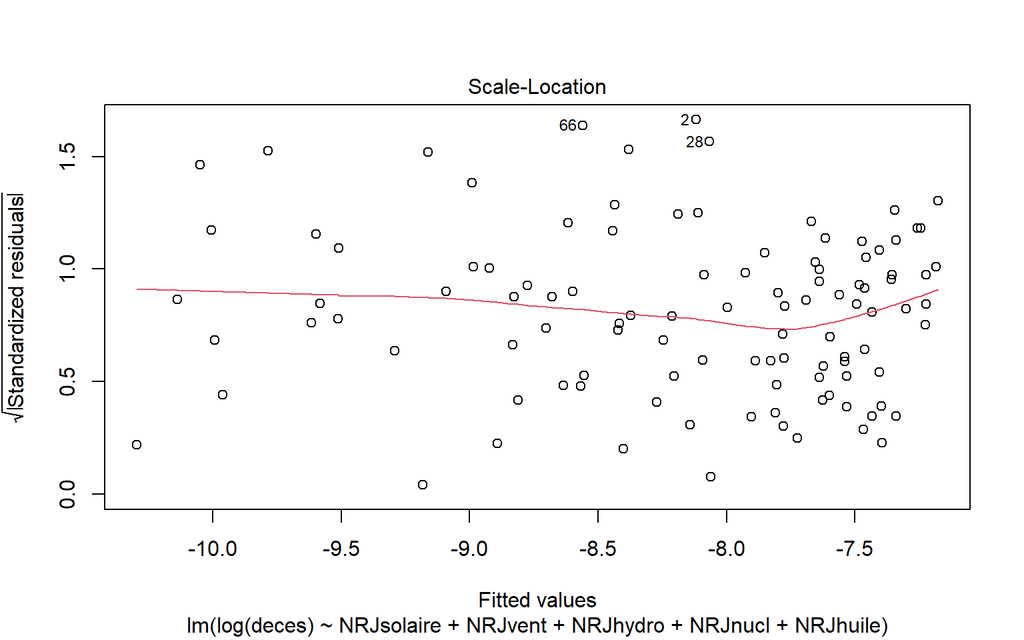

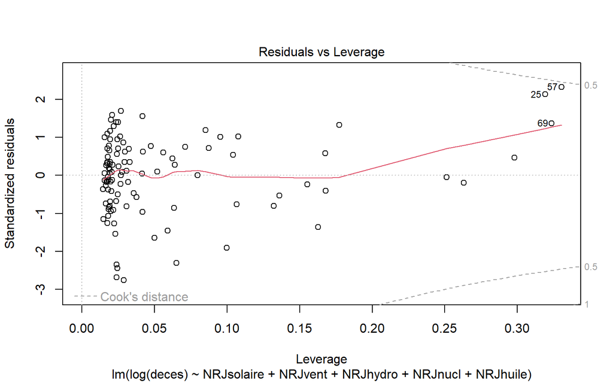

```r
# Conditions d'application
#par(mfrow=c(2,2))
plot(modelaj)
```

### Normalité

```r
shapiro.test(residuals(modelaj))
```

```
##
##  Shapiro-Wilk normality test
##
## data:  residuals(modelaj)
## W = 0.97396, p-value = 0.03359
```

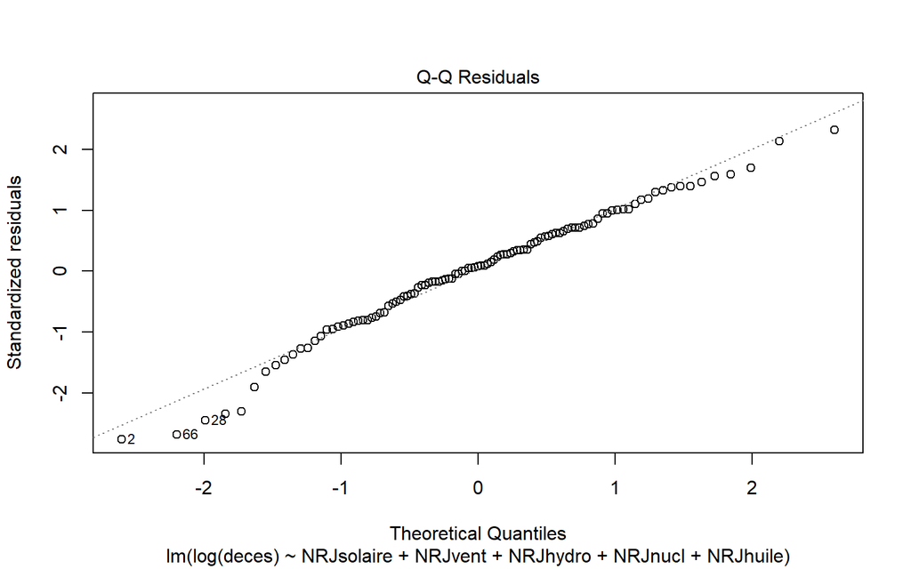

```r
plot(modelaj,2)
```

Je choisi un seuil $\alpha = 0.01$

Le test de shapiro indique une p-valeurs = 0.03359

La p-value est supérieur au niveau $\alpha$ choisi, alors l’hypotèse $H_0$ d’un échantillon provenant d’une population suit une loi normale est conservée.

De plus comme il y a beaucoup d’observations on peut regarder le QQ plot, et voir que la majorité des points suivent la droite de Henry ce qui est positif.

### Indépendence des résidus

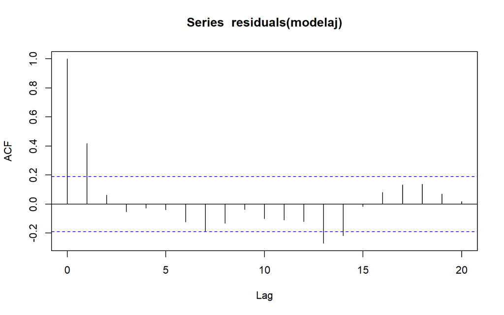

```r
library(see)
library(car)

acf(residuals(modelaj))
```

```r
car::vif(modelaj)
```

```
## NRJsolaire    NRJvent   NRJhydro    NRJnucl   NRJhuile
##   1.160675   1.146497   1.097125   1.049107   1.181041
```

### Evaluation de l’hypothèse d’homogénéité des résidus

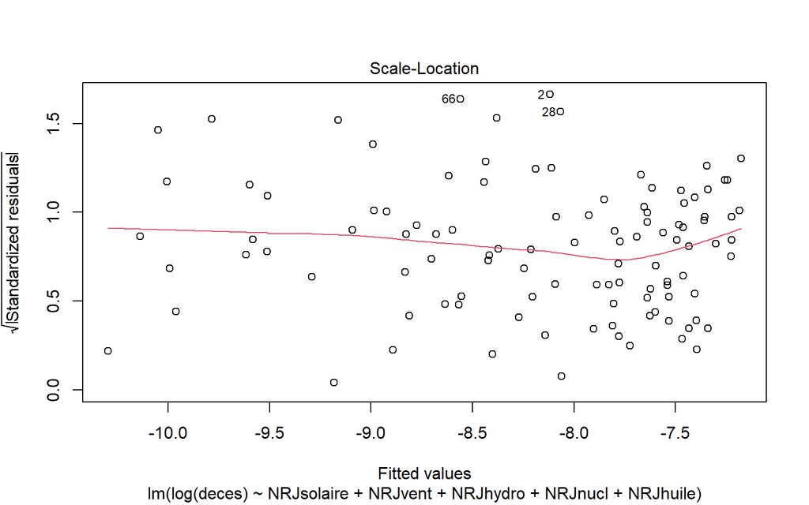

```r
plot(modelaj, 3)
```

```r
ncvTest(modelaj)
```

```
## Non-constant Variance Score Test
## Variance formula: ~ fitted.values
## Chisquare = 1.265631, Df = 1, p = 0.26059
```

Je choisi un seuil $\alpha$ de 1%

De même par le graphique on voit que les résidues sont éparpié de facon homogène et que la ligne rouge ne forme une droite ce qui confirme l’idée.

### Evaluation à posteriori de l’hypothèse de linéarité

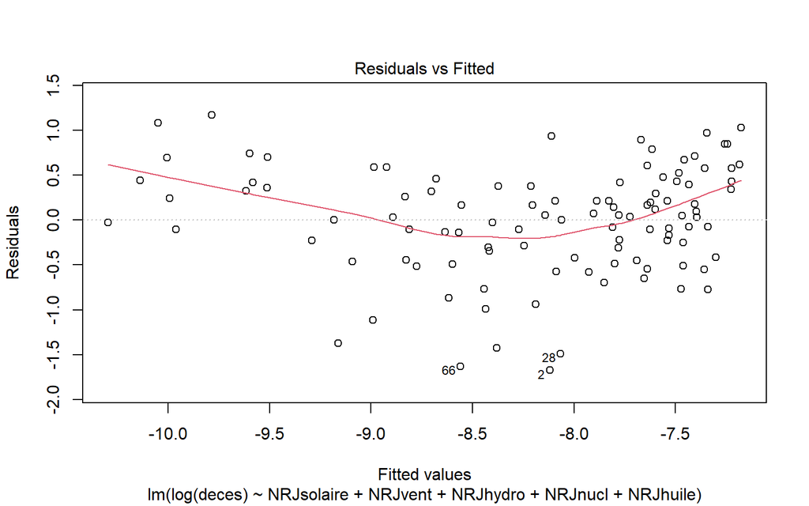

```r
plot(modelaj,1)
```

En conclusion ce modèle est bien meilleur que le modèle précedent.